# TidyTuesday_week5_2022

Jeanette Lyerly

6/3/2022

## Tidy Tuesday - week 5 - 2022

Week 5 of Tidy Tuesday is about dogs. In this markdown we will load some data, run some exploratory analysis, and make some kind of graph with the dog breed data.

Load packages.

### Load the data

Load the data.

I’ve got three data frames with data about dogs. Take a look at this.

```
## Rows: 195
## Columns: 17
## $ Breed                        <chr> "Retrievers (Labrador)", "French Bulldogs…
## $ `Affectionate With Family`   <dbl> 5, 5, 5, 5, 4, 5, 3, 5, 5, 5, 5, 3, 5, 4,…
## $ `Good With Young Children`   <dbl> 5, 5, 5, 5, 3, 5, 5, 3, 5, 3, 3, 5, 5, 5,…
## $ `Good With Other Dogs`       <dbl> 5, 4, 3, 5, 3, 3, 5, 3, 4, 4, 4, 3, 3, 3,…
## $ `Shedding Level`             <dbl> 4, 3, 4, 4, 3, 1, 3, 3, 3, 2, 4, 3, 1, 2,…
## $ `Coat Grooming Frequency`    <dbl> 2, 1, 2, 2, 3, 4, 2, 1, 2, 2, 2, 2, 5, 2,…
## $ `Drooling Level`             <dbl> 2, 3, 2, 2, 3, 1, 1, 3, 2, 2, 1, 1, 1, 3,…
## $ `Coat Type`                  <chr> "Double", "Smooth", "Double", "Double", "…
## $ `Coat Length`                <chr> "Short", "Short", "Medium", "Medium", "Sh…
## $ `Openness To Strangers`      <dbl> 5, 5, 3, 5, 4, 5, 3, 3, 4, 4, 4, 3, 5, 4,…
## $ `Playfulness Level`          <dbl> 5, 5, 4, 4, 4, 5, 4, 4, 4, 4, 4, 4, 4, 4,…
## $ `Watchdog/Protective Nature` <dbl> 3, 3, 5, 3, 3, 5, 2, 5, 4, 4, 5, 3, 5, 4,…
## $ `Adaptability Level`         <dbl> 5, 5, 5, 5, 3, 4, 4, 4, 4, 4, 4, 3, 5, 3,…
## $ `Trainability Level`         <dbl> 5, 4, 5, 5, 4, 5, 3, 5, 5, 4, 4, 5, 4, 4,…
## $ `Energy Level`               <dbl> 5, 3, 5, 3, 3, 4, 4, 3, 5, 3, 4, 5, 4, 4,…
## $ `Barking Level`              <dbl> 3, 1, 3, 1, 2, 4, 4, 1, 3, 5, 4, 3, 4, 3,…
## $ `Mental Stimulation Needs`   <dbl> 4, 3, 5, 4, 3, 5, 4, 5, 5, 3, 4, 5, 4, 4,…
```

```
## Rows: 195
## Columns: 11
## $ Breed       <chr> "Retrievers (Labrador)", "French Bulldogs", "German Shephe…
## $ `2013 Rank` <dbl> 1, 11, 2, 3, 5, 8, 4, 9, 13, 10, 24, 20, 6, 7, 16, 14, 18,…
## $ `2014 Rank` <dbl> 1, 9, 2, 3, 4, 7, 5, 10, 12, 11, 22, 18, 6, 8, 15, 13, 19,…
## $ `2015 Rank` <dbl> 1, 6, 2, 3, 4, 8, 5, 9, 11, 13, 20, 17, 7, 10, 15, 12, 18,…
## $ `2016 Rank` <dbl> 1, 6, 2, 3, 4, 7, 5, 8, 11, 13, 18, 16, 9, 10, 14, 12, 19,…
## $ `2017 Rank` <dbl> 1, 4, 2, 3, 5, 7, 6, 8, 10, 13, 15, 17, 9, 11, 14, 12, 19,…
## $ `2018 Rank` <dbl> 1, 4, 2, 3, 5, 7, 6, 8, 9, 12, 13, 15, 10, 11, 16, 14, 18,…
## $ `2019 Rank` <dbl> 1, 4, 2, 3, 5, 6, 7, 8, 9, 11, 10, 13, 12, 14, 17, 15, 16,…
## $ `2020 Rank` <dbl> 1, 2, 3, 4, 5, 6, 7, 8, 9, 10, 11, 12, 13, 14, 15, 16, 17,…
## $ links       <chr> "https://www.akc.org/dog-breeds/labrador-retriever/", "htt…
## $ Image       <chr> "https://www.akc.org/wp-content/uploads/2017/11/Labrador-R…
```

```
## Rows: 16
## Columns: 4
## $ Trait       <chr> "Affectionate With Family", "Good With Young Children", "G…
## $ Trait_1     <chr> "Independent", "Not Recommended", "Not Recommended", "No S…
## $ Trait_5     <chr> "Lovey-Dovey", "Good With Children", "Good With Other Dogs…
## $ Description <chr> "How affectionate a breed is likely to be with family memb…
```

```
##     Breed           Affectionate With Family Good With Young Children
##  Length:195         Min.   :0.000            Min.   :0.000
##  Class :character   1st Qu.:4.000            1st Qu.:3.000
##  Mode  :character   Median :5.000            Median :3.000
##                     Mean   :4.477            Mean   :3.867
##                     3rd Qu.:5.000            3rd Qu.:5.000
##                     Max.   :5.000            Max.   :5.000
##  Good With Other Dogs Shedding Level Coat Grooming Frequency Drooling Level
##  Min.   :0.000        Min.   :0.00   Min.   :0.000           Min.   :0.00
##  1st Qu.:3.000        1st Qu.:2.00   1st Qu.:2.000           1st Qu.:1.00
##  Median :3.000        Median :3.00   Median :2.000           Median :2.00
##  Mean   :3.513        Mean   :2.59   Mean   :2.277           Mean   :1.79
##  3rd Qu.:4.000        3rd Qu.:3.00   3rd Qu.:3.000           3rd Qu.:2.00
##  Max.   :5.000        Max.   :5.00   Max.   :5.000           Max.   :5.00
##   Coat Type         Coat Length        Openness To Strangers Playfulness Level
##  Length:195         Length:195         Min.   :0.000         Min.   :0.000
##  Class :character   Class :character   1st Qu.:3.000         1st Qu.:3.000
##  Mode  :character   Mode  :character   Median :3.000         Median :4.000
##                                        Mean   :3.467         Mean   :3.631
##                                        3rd Qu.:4.000         3rd Qu.:4.000
##                                        Max.   :5.000         Max.   :5.000
##  Watchdog/Protective Nature Adaptability Level Trainability Level
##  Min.   :0.000              Min.   :0.000      Min.   :0.000
##  1st Qu.:3.000              1st Qu.:3.000      1st Qu.:3.000
##  Median :4.000              Median :4.000      Median :4.000
##  Mean   :3.718              Mean   :3.774      Mean   :3.846
##  3rd Qu.:5.000              3rd Qu.:4.000      3rd Qu.:5.000
##  Max.   :5.000              Max.   :5.000      Max.   :5.000
##   Energy Level   Barking Level   Mental Stimulation Needs
##  Min.   :0.000   Min.   :0.000   Min.   :0.000
##  1st Qu.:3.000   1st Qu.:3.000   1st Qu.:3.000
##  Median :4.000   Median :3.000   Median :4.000
##  Mean   :3.723   Mean   :3.118   Mean   :3.662
##  3rd Qu.:4.000   3rd Qu.:4.000   3rd Qu.:4.000
##  Max.   :5.000   Max.   :5.000   Max.   :5.000
```

```
##     Breed             2013 Rank        2014 Rank        2015 Rank
##  Length:195         Min.   :  1.00   Min.   :  1.00   Min.   :  1.00
##  Class :character   1st Qu.: 44.75   1st Qu.: 45.75   1st Qu.: 44.75
##  Mode  :character   Median : 88.50   Median : 90.50   Median : 89.50
##                     Mean   : 88.66   Mean   : 92.20   Mean   : 90.34
##                     3rd Qu.:132.25   3rd Qu.:139.25   3rd Qu.:135.25
##                     Max.   :177.00   Max.   :184.00   Max.   :184.00
##                     NA's   :19       NA's   :19       NA's   :19
##    2016 Rank        2017 Rank        2018 Rank        2019 Rank
##  Min.   :  1.00   Min.   :  1.00   Min.   :  1.00   Min.   :  1.00
##  1st Qu.: 45.75   1st Qu.: 45.75   1st Qu.: 45.75   1st Qu.: 45.50
##  Median : 90.50   Median : 90.50   Median : 91.50   Median : 93.00
##  Mean   : 92.17   Mean   : 92.24   Mean   : 92.59   Mean   : 93.58
##  3rd Qu.:138.25   3rd Qu.:138.25   3rd Qu.:138.25   3rd Qu.:139.50
##  Max.   :189.00   Max.   :190.00   Max.   :191.00   Max.   :195.00
##  NA's   :19       NA's   :19       NA's   :19       NA's   :20
##    2020 Rank        links              Image
##  Min.   :  1.0   Length:195         Length:195
##  1st Qu.: 49.5   Class :character   Class :character
##  Median : 98.0   Mode  :character   Mode  :character
##  Mean   : 98.0
##  3rd Qu.:146.5
##  Max.   :195.0
##
```

```
##     Trait             Trait_1            Trait_5          Description
##  Length:16          Length:16          Length:16          Length:16
##  Class :character   Class :character   Class :character   Class :character
##  Mode  :character   Mode  :character   Mode  :character   Mode  :character
```

We have information about 195 dog breeds. Breed traits is lots of numeric data, with some categorical data for coat type, and coat length.  
Breed rank looks like data by year - popularity, and some links and images.  
Trait description has info about the different traits. Let’s look at the scales for that.

```
## # A tibble: 16 × 3
##    Trait                      Trait_1                    Trait_5
##    <chr>                      <chr>                      <chr>
##  1 Affectionate With Family   Independent                Lovey-Dovey
##  2 Good With Young Children   Not Recommended            Good With Children
##  3 Good With Other Dogs       Not Recommended            Good With Other Dogs
##  4 Shedding Level             No Shedding                Hair Everywhere
##  5 Coat Grooming Frequency    Monthly                    Daily
##  6 Drooling Level             Less Likely to Drool       Always Have a Towel
##  7 Coat Type                  -                          -
##  8 Coat Length                -                          -
##  9 Openness To Strangers      Reserved                   Everyone Is My Best Fr…
## 10 Playfulness Level          Only When You Want To Play Non-Stop
## 11 Watchdog/Protective Nature What's Mine Is Yours       Vigilant
## 12 Adaptability Level         Lives For Routine          Highly Adaptable
## 13 Trainability Level         Self-Willed                Eager to Please
## 14 Energy Level               Couch Potato               High Energy
## 15 Barking Level              Only To Alert              Very Vocal
## 16 Mental Stimulation Needs   Happy to Lounge            Needs a Job or Activity
```

### Explore the data

Let’s look at some distributions of values for the traits. Check for any odd data.

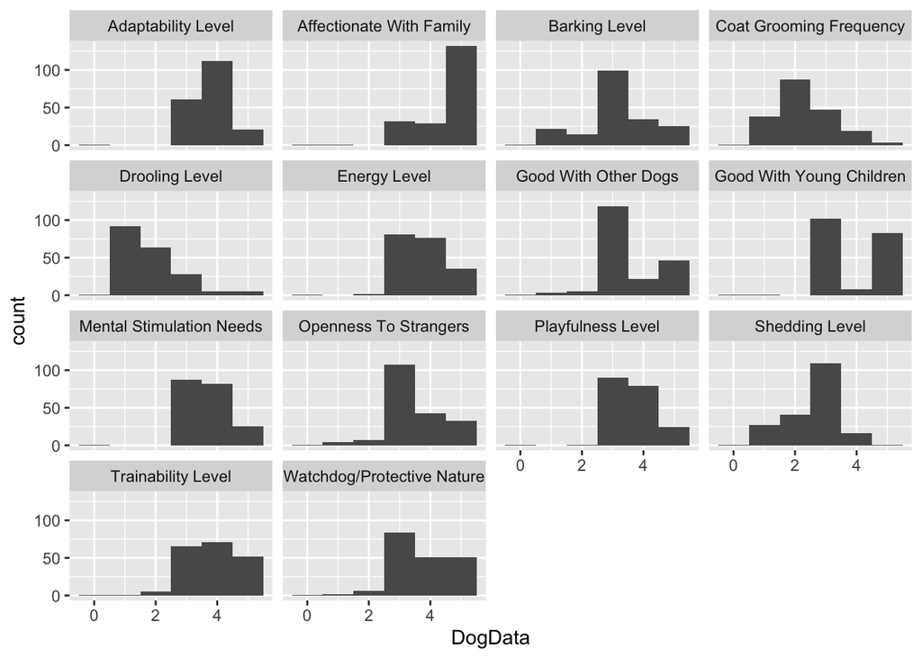

```
## # A tibble: 195 × 2
##    Breed                    mean
##    <chr>                   <dbl>
##  1 Plott Hounds             0
##  2 Azawakhs                 2.36
##  3 Anatolian Shepherd Dogs  2.57
##  4 Basenjis                 2.57
##  5 Bergamasco Sheepdogs     2.57
##  6 Sloughis                 2.64
##  7 Afghan Hounds            2.71
##  8 Akitas                   2.79
##  9 Borzois                  2.79
## 10 Briards                  2.79
## # … with 185 more rows
```

```
## # A tibble: 14 × 3
## # Groups:   Trait [14]
##    Breed        Trait                      DogData
##    <chr>        <chr>                        <dbl>
##  1 Plott Hounds Affectionate With Family         0
##  2 Plott Hounds Good With Young Children         0
##  3 Plott Hounds Good With Other Dogs             0
##  4 Plott Hounds Shedding Level                   0
##  5 Plott Hounds Coat Grooming Frequency          0
##  6 Plott Hounds Drooling Level                   0
##  7 Plott Hounds Openness To Strangers            0
##  8 Plott Hounds Playfulness Level                0
##  9 Plott Hounds Watchdog/Protective Nature       0
## 10 Plott Hounds Adaptability Level               0
## 11 Plott Hounds Trainability Level               0
## 12 Plott Hounds Energy Level                     0
## 13 Plott Hounds Barking Level                    0
## 14 Plott Hounds Mental Stimulation Needs         0
```

This Plott Hounds data looks like an error - all the traits are 0 (or Plott hounds are very unpopular). In either case, remove this from the data set. Look at this again.

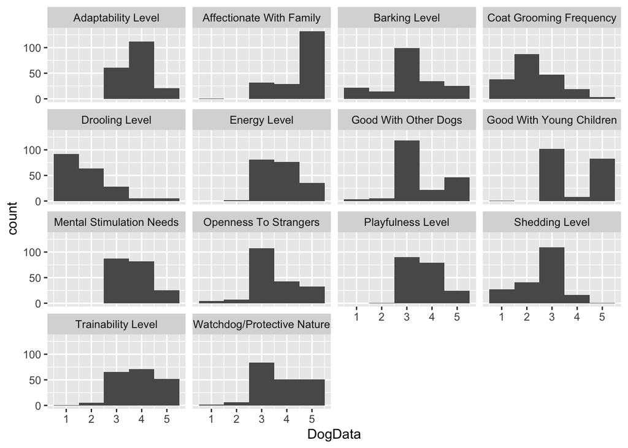

This looks better.

We can see ranges over the scale for barking, grooming, and shedding. Otherwise we can see there are a few that are at one end of the scale or the other (some not very adaptable, not good with kids, etc.).

Questions we might ask if we were thinking about a dog…

### Grooming and drool

Two important questions - how much grooming, and how much drool?  
drooling level 1 = no drooling, 5 = get a towel  
grooming frequency 1 = monthly, 5 = daily  
So in the scale 1 is less drool and less grooming, and 5 is slobbery and needs a lot of grooming. Select the dogs where grooming needs and drooling are <=2.

```
##
##  1  2  3  4  5
## 92 64 28  5  5
```

```
##
##  1  2  3  4  5
## 38 87 47 19  3
```

Freq table for Drooling

| Scale 0-5 | Freq |
| --- | --- |
| 1 | 92 |
| 2 | 64 |
| 3 | 28 |
| 4 | 5 |
| 5 | 5 |

Freq table for Grooming

| Scale 0-5 | Freq |
| --- | --- |
| 1 | 38 |
| 2 | 87 |
| 3 | 47 |
| 4 | 19 |
| 5 | 3 |

```
## [1] 98
```

We’ve got 98 breeds here with low grooming requirements (<= 2) and also that don’t drool (<=2).

Next, consider how much exercise these dogs need. Let’s face it - as a lazy person I would need a laz(ier) dog.

### Exercise and mental stimulation

What are the distributions of these traits among the subset of dogs that don’t require much grooming and don’t drool? Make some histograms.

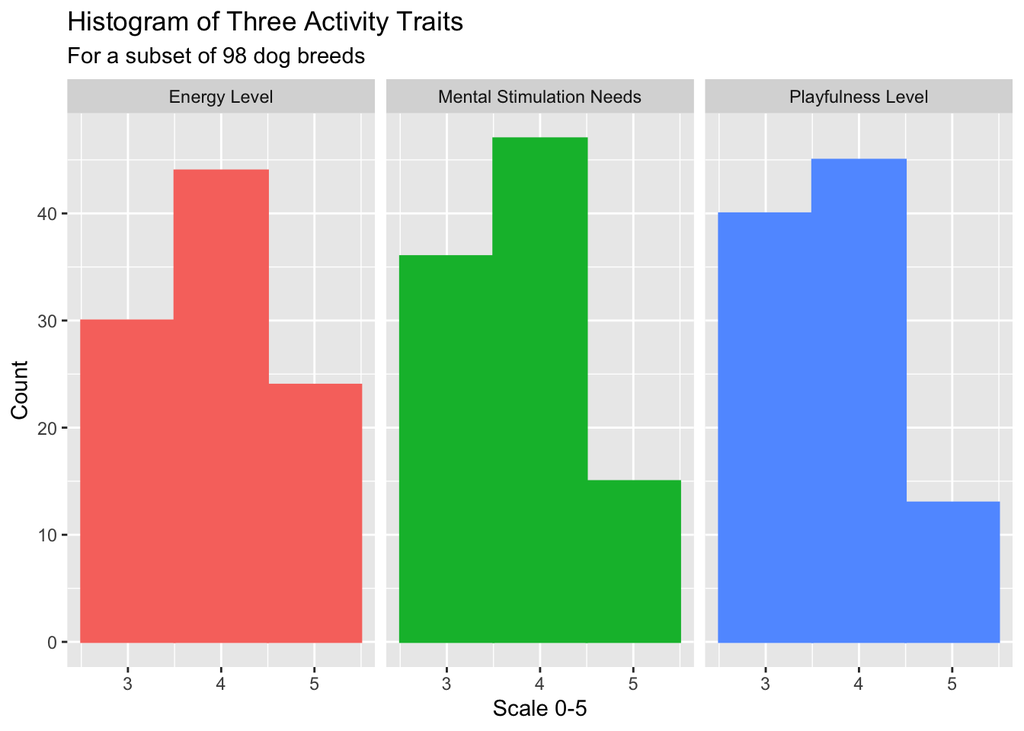

The range we see here is from 3 to 5. We’ve got some dogs here with different activity levels. No very lazy dogs (no 1-2’s), but some high energy dogs.

Look among these for a trainable, lazy dog. Graph the energy level vs trainability.

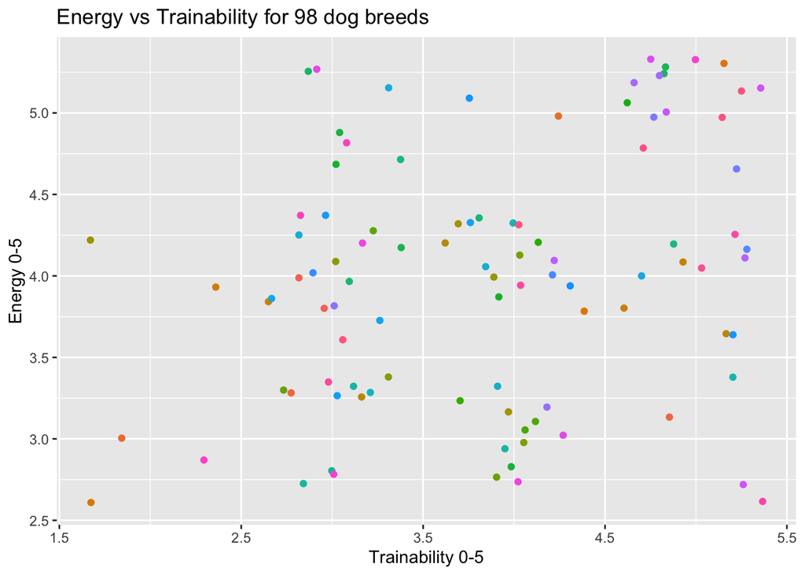

Label that group on the bottom right that is trainable and kind-of lazy.

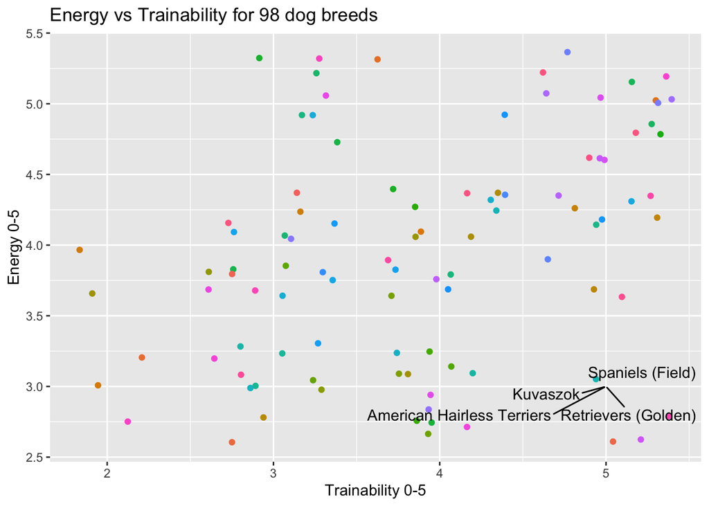

Get the stats on these.

Breeds with low grooming and less drool who are trainable and (sort-of) lazy

| Breed | Affectionate With Family | Good With Young Children | Good With Other Dogs | Shedding Level | Coat Grooming Frequency | Drooling Level | Coat Type | Coat Length | Openness To Strangers | Playfulness Level | Watchdog/Protective Nature | Adaptability Level | Trainability Level | Energy Level | Barking Level | Mental Stimulation Needs |
| --- | --- | --- | --- | --- | --- | --- | --- | --- | --- | --- | --- | --- | --- | --- | --- | --- |
| Retrievers (Golden) | 5 | 5 | 5 | 4 | 2 | 2 | Double | Medium | 5 | 4 | 3 | 5 | 5 | 3 | 1 | 4 |
| American Hairless Terriers | 5 | 5 | 3 | 1 | 1 | 1 | Hairless | Short | 3 | 3 | 3 | 5 | 5 | 3 | 3 | 3 |
| Spaniels (Field) | 5 | 5 | 4 | 3 | 2 | 2 | Smooth | Medium | 4 | 3 | 3 | 4 | 5 | 3 | 3 | 3 |
| Kuvaszok | 5 | 3 | 3 | 3 | 2 | 2 | Double | Medium | 3 | 3 | 5 | 4 | 5 | 3 | 3 | 3 |

Last thing we might consider - barking. Our house is lazy and quiet.

### Barking

Among the dogs we’ve selected, who is the quietest?

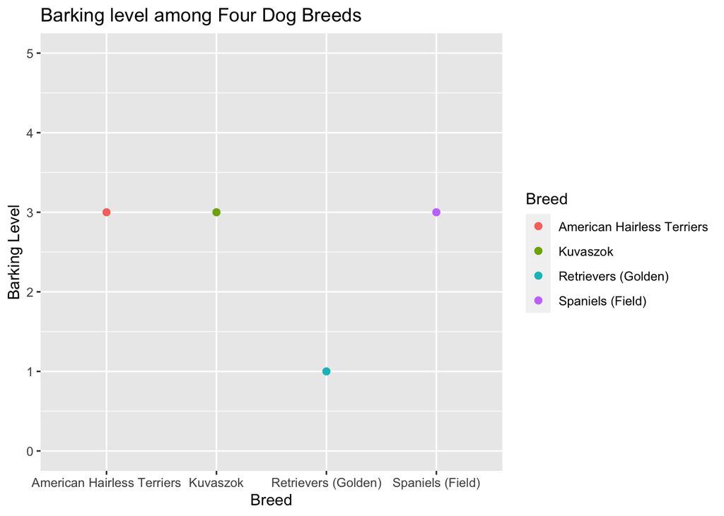

### Conclusions

Get a golden retriever.